# Milestone Report

Francisco Martín

November, 2018

## Introduction

This is my Milestone report for Data Science Capstone course. Here I will process data and create three important files for the project. This three files will contain 2-grams, 3-grams and 4-grams for my future text predictor.

## Exploratory analysis

First of all I will make some exploratory analysis of the data. Before that, data should be downloaded (if needed) and loaded:

```r
url <- "https://d396qusza40orc.cloudfront.net/dsscapstone/dataset/Coursera-SwiftKey.zip"
fileName <- "Coursera-SwiftKey.zip"
path <- file.path(getwd(),fileName)

if (!file.exists(path)){
        download.file(url,path)
}

folderData <- "final"
pathFolder <- file.path(getwd(),folderData)

if(!file.exists(pathFolder)){
        unzip(path)
}

englishFolder <- file.path(pathFolder, "en_US")
blogsPath <- file.path(englishFolder,"en_US.blogs.txt")
newsPath <- file.path(englishFolder,"en_US.news.txt")
twitterPath <-file.path(englishFolder,"en_US.twitter.txt")

# I will only work on english data.

twitterReaded <- readLines(twitterPath)
blogsReaded <- readLines(blogsPath)
newsReaded <- readLines(newsPath)
```

Once data is loaded, I will check some features of the data:

```r
# Size of the files:

sizeBlog <- file.size(blogsPath)/(1024^2)
sizeNews <- file.size(newsPath)/(1024^2)
sizeTwitter <- file.size(twitterPath)/(1024^2)

# Number of lines:

linesTwitter <- length(twitterReaded)
linesBlog <- length(blogsReaded)
linesNews <- length(newsReaded)

# Number of words:

wordsTwitter <- sum(stri_count_words(twitterReaded))
wordsBlogs <- sum(stri_count_words(blogsReaded))
wordsNews <- sum(stri_count_words(newsReaded))
```

Sizes are 159.364069Mb for twitter set, 200.4242077Mb for blog and 196.2775126Mb for news. Also, the number of lines are between 2360148 for twitter set and 77259 for news, and number words are between 38154238 for blogs and 2693898 for news.

Files are too big. If I want to make my predictor to work in, per example, a mobile phone, I need to use a much smaller subset. Just make it randomly with all three datasets and save it in a new file:

```r
set.seed(1994)
sampleSize <- 15000
sampleTwitter <- sample(twitterReaded, size = sampleSize/3, replace = TRUE)
sampleBlogs <- sample(blogsReaded, size = sampleSize/3, replace = TRUE)
sampleNews <- sample(newsReaded, size = sampleSize/3, replace = TRUE)

smallSubset <- c(sampleTwitter, sampleBlogs, sampleNews)

smallSubsetPath <- file.path(englishFolder,"subsetNotClean.txt")
if (!file.exists(smallSubsetPath)){writeLines(smallSubset, smallSubsetPath)}
```

## Prepare data

Here I have created my subset for training my model. Before training it, I need to process all data and clean it, removing punctuations, emoticons, numbers, URLs, multiple whitespaces, and converting all letters to lowercase. For this I will use text mining package (tm):

```r
# First I create a couple of functions for removing different things:
rvThings <- function(x,pattern){gsub(pattern,"",x)}
rvEmoticons <- function (x) {x <- iconv(x, "UTF-8", "ASCII", sub="")}

# And here I clean data
textTM <- Corpus(VectorSource(smallSubset))
textTM <- tm_map(textTM, removePunctuation)                        # remove punctuation
textTM <- tm_map(textTM, rvEmoticons)                               # remove URL
textTM <- tm_map(textTM, removeNumbers)                            # remove numbers
textTM <- tm_map(textTM, rvThings,"(f|ht)tp(s?)://(.*)[.][a-z]+")  # remove URL
textTM <- tm_map(textTM, stripWhitespace)                          # remove multiple whitespace
textTM <- tm_map(textTM, content_transformer(tolower))             # convert to lowercase
```

Also I have to remove profane words. Just tiping in Google “Profane word list” I found a list, and I will use it for removing this words:

```r
urlProfane<- "http://www.cs.cmu.edu/~biglou/resources/bad-words.txt"
pathProfane <- file.path(englishFolder,"profaneWords.txt")
if(!file.exists(pathProfane)) {download.file(urlProfane,pathProfane)}

profaneReaded <- readLines(pathProfane)
textTM <- tm_map(textTM,removeWords,profaneReaded)
# Once data is clean, "rewrite" it as plain text
textTM <- tm_map(textTM,PlainTextDocument)
```

Here data is clean. Just proceed to make n-grams of it.

## N-Grams

N-Grams are set of N words which appears in a given dataset. In order to create a good text predictor, I will generate the set of 2-Grams, 3-Grams and 4-Grams of my subset, for comparing it to 3~1 final words of the future input of the text predictor. In order to do it, I will use RWeka package:

First 2-grams:

```r
bigrams <- NGramTokenizer(textTM, Weka_control(min=2,max=2))
bigrams <- data.frame(table(bigrams)) # convert it to a data frame
bigrams <- bigrams[order(bigrams$Freq,decreasing = TRUE),] #Order in more common
names(bigrams) <- c("words","freq")  # Rename columns of bigrams dataframe
bigrams$words <- as.character(bigrams$words)
wordsBigrams <- strsplit(bigrams$words,split=" ")
bigrams <- transform(bigrams, word_1 = sapply(wordsBigrams,"[[",1),
                      word_2 = sapply(wordsBigrams,"[[",2))
bigrams2 <- data.frame(word_1 = bigrams$word_1, word_2 = bigrams$word_2,
                       freq = bigrams$freq, stringsAsFactors=FALSE)
```

And I will proceed equaly to 3-grams and 4-grams:

```r
trigrams <- NGramTokenizer(textTM, Weka_control(min=3,max=3))
trigrams <- data.frame(table(trigrams))
trigrams <- trigrams[order(trigrams$Freq,decreasing = TRUE),]
names(trigrams) <- c("words","freq")
trigrams$words <- as.character(trigrams$words)
wordsTrigrams <- strsplit(trigrams$words,split=" ")
trigrams <- transform(trigrams, word_1 = sapply(wordsTrigrams,"[[",1),
                     word_2 = sapply(wordsTrigrams,"[[",2),
                     word_3 = sapply(wordsTrigrams,"[[",3))
trigrams2 <- data.frame(word_1 = trigrams$word_1, word_2 = trigrams$word_2,
                         word_3 = trigrams$word_3,
                         freq = trigrams$freq, stringsAsFactors=FALSE)


quadgrams <- NGramTokenizer(textTM, Weka_control(min=4,max=4))
quadgrams <- data.frame(table(quadgrams))
quadgrams <- quadgrams[order(quadgrams$Freq,decreasing = TRUE),]
names(quadgrams) <- c("words","freq")
quadgrams$words <- as.character(quadgrams$words)
wordsQuadgrams <- strsplit(quadgrams$words,split=" ")
quadgrams <- transform(quadgrams, word_1 = sapply(wordsQuadgrams,"[[",1),
                     word_2 = sapply(wordsQuadgrams,"[[",2),
                     word_3 = sapply(wordsQuadgrams,"[[",3),
                     word_4 = sapply(wordsQuadgrams,"[[",4))
quadgrams2 <- data.frame(word_1 = quadgrams$word_1,  word_2 = quadgrams$word_2,
                         word_3 = quadgrams$word_3, word_4 = quadgrams$word_4,
                         freq = quadgrams$freq, stringsAsFactors=FALSE)
```

Now just save this N-Grams into r files, because they will be used in the text predictor:

```r
pathApp <- file.path(getwd(),"App")
if(!dir.exists(pathApp)){dir.create(pathApp)}


bigramsPath <- file.path(pathApp,"bigrams.RData")
trigramsPath <- file.path(pathApp,"trigrams.RData")
quadgramsPath <- file.path(pathApp,"quadgrams.RData")

if(!file.exists(bigramsPath)){
saveRDS(bigrams2, file = bigramsPath)
saveRDS(trigrams2, file = trigramsPath)
saveRDS(quadgrams2, file = quadgramsPath)}
```

# Some N-Grams plots

Here we have isolated most common N-grams. In order to see which they are, we can plot the 20 most common in bigrams, trigrams and quadgrams. Let`s see:

First, and using ggplot, I am going to define a plot function:

```r
top20 <- function(df, title) {
    df <- df[order(df$freq,decreasing = TRUE),]
    df <- df[1:20,]
    df$words <- factor(df$words, levels = df$words[order(-df$freq)])
    ggplot(df, aes(x = words, y = freq)) +
        geom_bar(stat = "identity", fill = "dodgerblue3", colour = "gray40") +
        labs(title = title, x="N-Gram", y="Count") +
        theme(axis.text.x = element_text(angle=60, size=12, hjust = 1),
              axis.title = element_text(size=14, face="bold"),
              plot.title = element_text(size=16, face="bold"))
}
```

And plot from bigrams, trigrans and quadgrams:

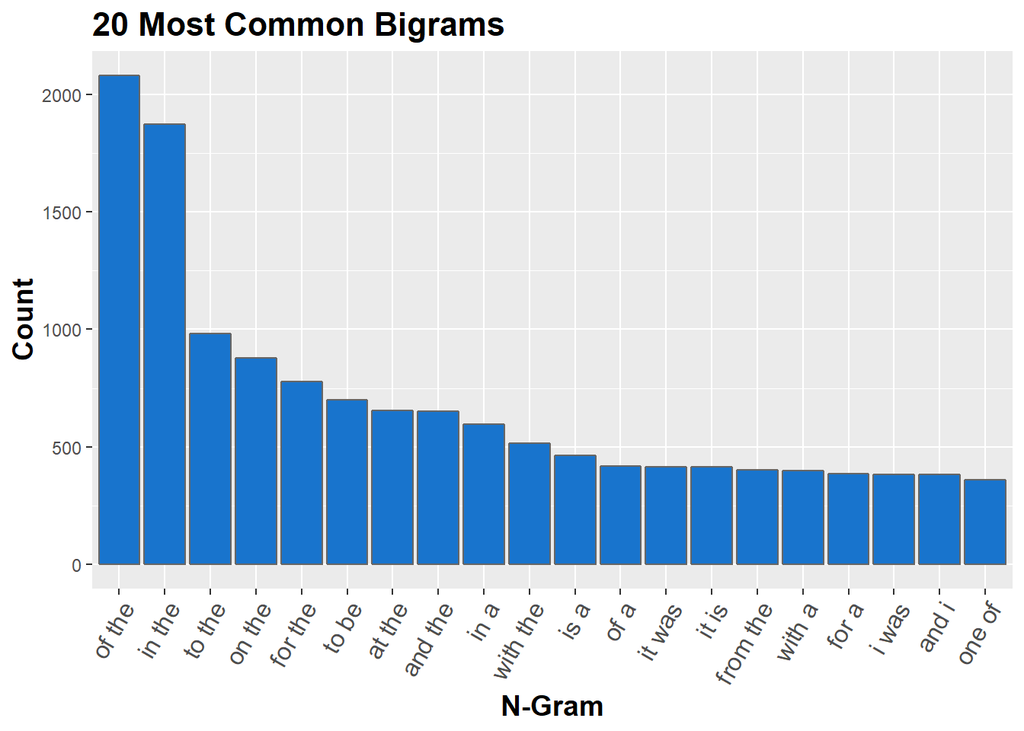

```r
top20(bigrams, "20 Most Common Bigrams")
```

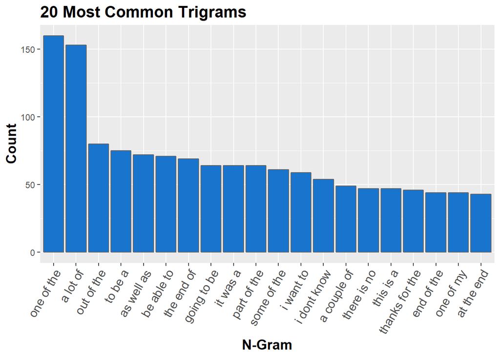

```r
top20(trigrams, "20 Most Common Trigrams")
```

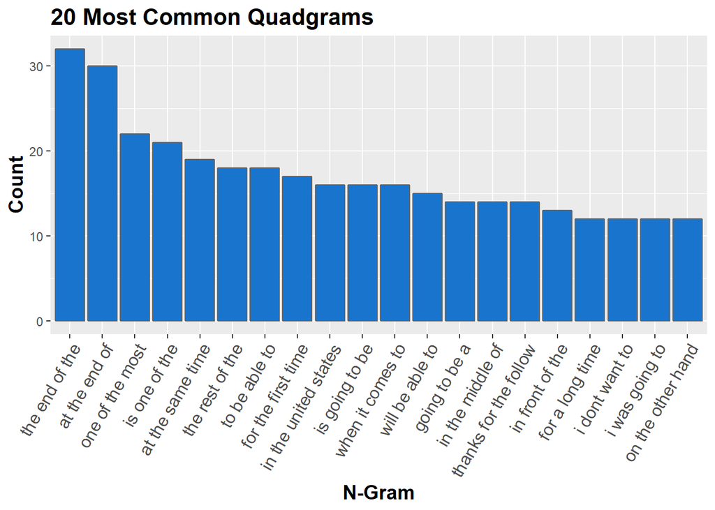

```r
top20(quadgrams, "20 Most Common Quadgrams")
```